# Multiple comparisons in R

11/09/2018

Note: This was edited *after* the recitation to do Bonferroni tests correctly.

## Packages and data sets

```r
library(dplyr)
library(ggplot2)
library(DescTools)
library(dunn.test)
```

## Plan for today

- Tukey-Kramer tests with `TukeyHSD()`
- Bonferroni test for specific comparisons
- Dunnett's test with `DunnettTest()`
- Dunn's test with `dunn.test()`
- more fun with `ggplot2`
  - putting letters on plots with `geom_text()`
  - reordering plotted data with `factor()`

## But first… (a note about cheatsheets)

## Tukey-Kramer tests with `TukeyHSD()`

The Tukey-Kramer test runs all possible pairwise comparisons (all-ways comparisons) and produces a summary of which pairs are statistically different

```r
titanic <- read.csv("titanic.csv")
titanic.aov <- aov(fare ~ nationality, data = titanic)
anova(titanic.aov)
```

```
## Analysis of Variance Table
##
## Response: fare
##               Df  Sum Sq Mean Sq F value    Pr(>F)
## nationality    2  318064  159032  65.195 < 2.2e-16 ***
## Residuals   1305 3183336    2439
## ---
## Signif. codes:  0 '***' 0.001 '**' 0.01 '*' 0.05 '.' 0.1 ' ' 1
```

```r
TukeyHSD(titanic.aov)
```

```
##   Tukey multiple comparisons of means
##     95% family-wise confidence level
##
## Fit: aov(formula = fare ~ nationality, data = titanic)
##
## $nationality
##                        diff        lwr       upr     p adj
## British-American -41.259939 -51.092070 -31.42781 0.0000000
## other-American   -38.179609 -46.545243 -29.81398 0.0000000
## other-British      3.080329  -4.828375  10.98903 0.6316035
```

## Try on your own!

Try using `TukeyHSD()` on the air quality data set. Then compare the p-values you got from Tukey HSD to those you got from the Bonferroni test.

```r
air.aov <- aov(Ozone ~ factor(Month), data = airquality)
anova(air.aov)
```

```
## Analysis of Variance Table
##
## Response: Ozone
##                Df Sum Sq Mean Sq F value    Pr(>F)
## factor(Month)   4  29438  7359.5  8.5356 4.827e-06 ***
## Residuals     111  95705   862.2
## ---
## Signif. codes:  0 '***' 0.001 '**' 0.01 '*' 0.05 '.' 0.1 ' ' 1
```

## Tukey-Kramer tests with `TukeyHSD()`

```r
TukeyHSD(air.aov)
```

```
##   Tukey multiple comparisons of means
##     95% family-wise confidence level
##
## Fit: aov(formula = Ozone ~ factor(Month), data = airquality)
##
## $`factor(Month)`
##            diff         lwr       upr     p adj
## 6-5   5.8290598 -25.6630930 37.321213 0.9858842
## 7-5  35.5000000  12.9158068 58.084193 0.0002795
## 8-5  36.3461538  13.7619606 58.930347 0.0001869
## 9-5   7.8328912 -14.1594735 29.825256 0.8603562
## 7-6  29.6709402  -1.8212127 61.163093 0.0749128
## 8-6  30.5170940  -0.9750588 62.009247 0.0622826
## 9-6   2.0038314 -29.0666371 33.074300 0.9997676
## 8-7   0.8461538 -21.7380394 23.430347 0.9999733
## 9-7 -27.6671088 -49.6594735 -5.674744 0.0061535
## 9-8 -28.5132626 -50.5056273 -6.520898 0.0043387
```

## Bonferroni Test

## Bonferroni test

- More powerful because it's on a subset of all possible comparisons.
- Uses pooled standard deviation from ANOVA, so better than doing individual t-tests.

\[ \alpha^* = \frac{\alpha}{n_{tests}} \] *OR*

\[ p^* = p \times n_{tests} \]

## Implementing Bonferroni test in R

1. Do ANOVA, if significant…
2. Choose comparisons of interest
3. Use `pairwise.t.test()` with **no** p-value adjustment
4. Adjust p-values from comparisons of interest with `p.adjust()` (or using math)

## Example: `airquality`

Does Ozone differ by Month?

```r
head(airquality)
```

```
##   Ozone Solar.R Wind Temp Month Day
## 1    41     190  7.4   67     5   1
## 2    36     118  8.0   72     5   2
## 3    12     149 12.6   74     5   3
## 4    18     313 11.5   62     5   4
## 5    NA      NA 14.3   56     5   5
## 6    28      NA 14.9   66     5   6
```

## Step 1: ANOVA

(note: `Month` has to be manually converted to a factor)

```r
ozone.aov <- aov(Ozone ~ factor(Month), data = airquality)
anova(ozone.aov)
```

```
## Analysis of Variance Table
##
## Response: Ozone
##                Df Sum Sq Mean Sq F value    Pr(>F)
## factor(Month)   4  29438  7359.5  8.5356 4.827e-06 ***
## Residuals     111  95705   862.2
## ---
## Signif. codes:  0 '***' 0.001 '**' 0.01 '*' 0.05 '.' 0.1 ' ' 1
```

## Visualize Data

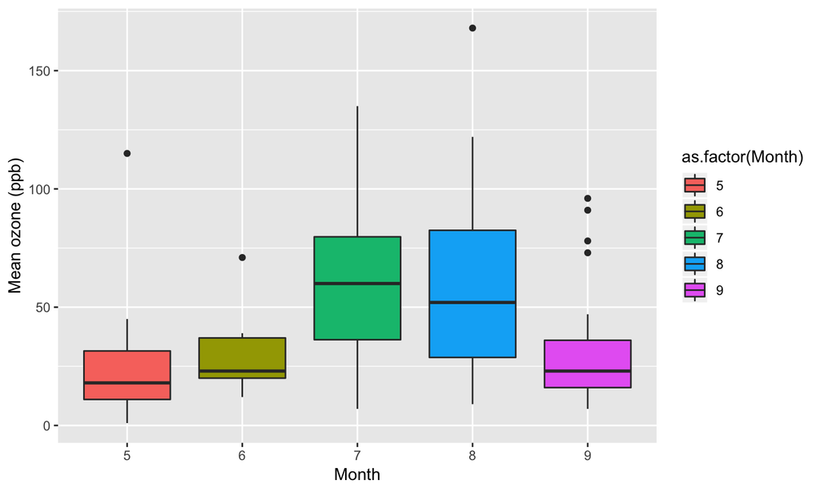

## Step 2: choose comparisons

Let's say you just want to know about how summer months compare to eachother

Comparisons of interest:

- June vs. July
- June vs. August
- July vs. August

## Step 3: `pairwise.t.test()`

```r
pairwise.t.test(airquality$Ozone, airquality$Month, p.adjust.method = "none")
```

```
##
##  Pairwise comparisons using t tests with pooled SD
##
## data:  airquality$Ozone and airquality$Month
##
##   5       6       7       8
## 6 0.60877 -       -       -
## 7 2.9e-05 0.01023 -       -
## 8 1.9e-05 0.00831 0.91744 -
## 9 0.32545 0.85838 0.00070 0.00048
##
## P value adjustment method: none
```

## Step 4: Adjust p-values for comparisons of interest

- June vs. July: p = 0.01023
- June vs. August: p = 0.00831
- July vs. August: p = 0.91744

```r
ps <- c(0.01023, 0.00831, 0.91744)
p.adjust(ps, method = "bonf")
```

```
## [1] 0.03069 0.02493 1.00000
```

```r
ps * length(ps) #does almost the same thing
```

```
## [1] 0.03069 0.02493 2.75232
```

## Dunnett's test with `DunnettTest()`

Dunnett's test runs pairwise comparisons of experimental groups against a control (many-to-one comparisons) and produces a summary of which pairs are statistically different

```r
library(DescTools)

DunnettTest(weight ~ feed, data = chickwts, control = "soybean")
```

```
##
##   Dunnett's test for comparing several treatments with a control :
##     95% family-wise confidence level
##
## $soybean
##                        diff     lwr.ci    upr.ci   pval
## casein-soybean     77.15476   21.23661 133.07291 0.0031 **
## horsebean-soybean -86.22857 -145.08073 -27.37642 0.0016 **
## linseed-soybean   -27.67857  -83.59672  28.23958 0.5943
## meatmeal-soybean   30.48052  -26.78991  87.75095 0.5260
## sunflower-soybean  82.48810   26.56994 138.40625 0.0014 **
##
## ---
## Signif. codes:  0 '***' 0.001 '**' 0.01 '*' 0.05 '.' 0.1 ' ' 1
```

## Dunnett's test with `DunnettTest()`

Try using `DunnettTest()` on the air quality data set!

```r
DunnettTest(Ozone ~ factor(Month), data = airquality, control = "9")
```

```
##
##   Dunnett's test for comparing several treatments with a control :
##     95% family-wise confidence level
##
## $`9`
##          diff     lwr.ci   upr.ci   pval
## 5-9 -7.832891 -27.624133 11.95835 0.7431
## 6-9 -2.003831 -29.964588 25.95692 0.9994
## 7-9 27.667109   7.875867 47.45835 0.0027 **
## 8-9 28.513263   8.722021 48.30450 0.0019 **
##
## ---
## Signif. codes:  0 '***' 0.001 '**' 0.01 '*' 0.05 '.' 0.1 ' ' 1
```

## Dunn's test with `dunn.test()`

Dunn's test is for non-parametric multiple comparisons (ANOVA vs. Kruskal-Wallis)

I remember last year there being some confusion about the p-value adjustment method. I think the book/slides don't teach an optional adjustment method, but Dunn's method was equivalent to bonferroni I think. Maybe.

```r
library(dunn.test)
dunn.test(InsectSprays$count, InsectSprays$spray)
```

```
##   Kruskal-Wallis rank sum test
##
## data: x and group
## Kruskal-Wallis chi-squared = 54.6913, df = 5, p-value = 0
##
##
##                            Comparison of x by group
##                                 (No adjustment)
## Col Mean-|
## Row Mean |          A          B          C          D          E
## ---------+-------------------------------------------------------
##        B |  -0.312733
##          |     0.3772
##        C |   4.774077   5.086811
##          |    0.0000*    0.0000*
##        D |   3.117565   3.430299  -1.656512
##          |    0.0009*    0.0003*     0.0488
##        E |   3.850535   4.163269  -0.923542   0.732969
##          |    0.0001*    0.0000*     0.1779     0.2318
##        F |  -0.405576  -0.092842  -5.179654  -3.523142  -4.256112
##          |     0.3425     0.4630    0.0000*    0.0002*    0.0000*
##
## alpha = 0.05
## Reject Ho if p <= alpha/2
```

## Dunn's test with `dunn.test()`

```r
dunn.test(InsectSprays$count, InsectSprays$spray, method = "bonferroni")
```

```
##   Kruskal-Wallis rank sum test
##
## data: x and group
## Kruskal-Wallis chi-squared = 54.6913, df = 5, p-value = 0
##
##
##                            Comparison of x by group
##                                  (Bonferroni)
## Col Mean-|
## Row Mean |          A          B          C          D          E
## ---------+-------------------------------------------------------
##        B |  -0.312733
##          |     1.0000
##        C |   4.774077   5.086811
##          |    0.0000*    0.0000*
##        D |   3.117565   3.430299  -1.656512
##          |    0.0137*    0.0045*     0.7321
##        E |   3.850535   4.163269  -0.923542   0.732969
##          |    0.0009*    0.0002*     1.0000     1.0000
##        F |  -0.405576  -0.092842  -5.179654  -3.523142  -4.256112
##          |     1.0000     1.0000    0.0000*    0.0032*    0.0002*
##
## alpha = 0.05
## Reject Ho if p <= alpha/2
```

## Plotting the results of multiple comparisons

## Step 1:

Stare at the test output, and decide what the letters are

```r
titanic.aov <- aov(fare ~ nationality, data = titanic)
anova(titanic.aov)
```

```
## Analysis of Variance Table
##
## Response: fare
##               Df  Sum Sq Mean Sq F value    Pr(>F)
## nationality    2  318064  159032  65.195 < 2.2e-16 ***
## Residuals   1305 3183336    2439
## ---
## Signif. codes:  0 '***' 0.001 '**' 0.01 '*' 0.05 '.' 0.1 ' ' 1
```

```r
TukeyHSD(titanic.aov)
```

```
##   Tukey multiple comparisons of means
##     95% family-wise confidence level
##
## Fit: aov(formula = fare ~ nationality, data = titanic)
##
## $nationality
##                        diff        lwr       upr     p adj
## British-American -41.259939 -51.092070 -31.42781 0.0000000
## other-American   -38.179609 -46.545243 -29.81398 0.0000000
## other-British      3.080329  -4.828375  10.98903 0.6316035
```

## Step 2:

Stare at the ggplot output, and decide where the letters should go

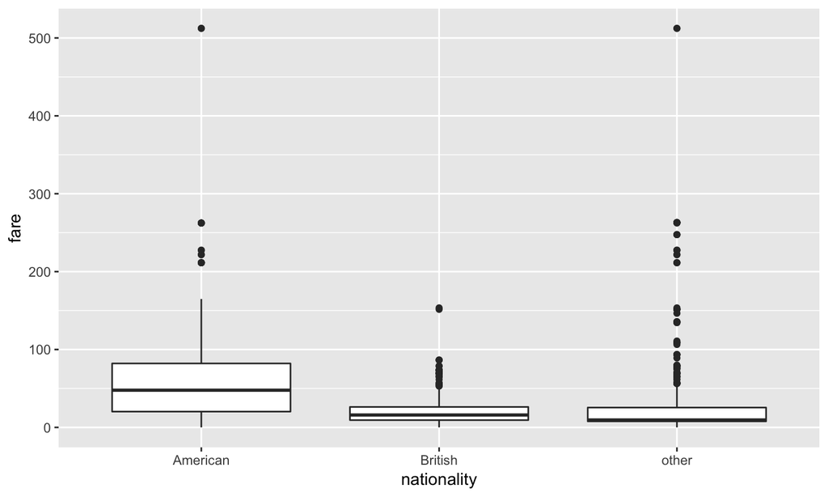

```r
p <- ggplot(titanic, aes(x = nationality, y = fare))
p + geom_boxplot()
```

## Step 2:

Stare at the ggplot output, and decide where the letters should go

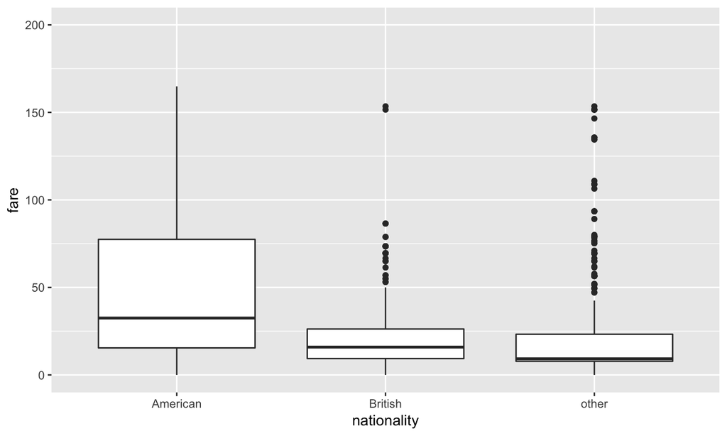

```r
p <- ggplot(titanic, aes(x = nationality, y = fare))
p + geom_boxplot() + ylim(0,200)
```

## Step 3:

Make a dataframe with your label information

```r
label_table <- data.frame(x.valuez = c(1,2,3),
                          y.valuez = 175,
                          letterz = c("a","b","b"))
label_table
```

```
##   x.valuez y.valuez letterz
## 1        1      175       a
## 2        2      175       b
## 3        3      175       b
```

## Step 4:

Put it all together!

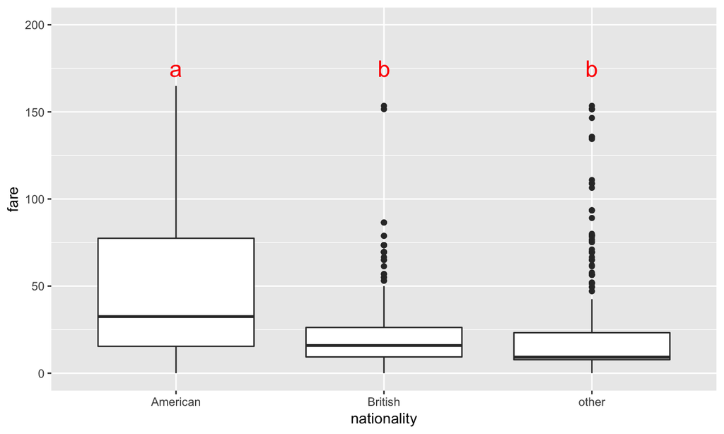

```r
p <- ggplot(titanic, aes(x = nationality, y = fare))
p + geom_boxplot() + ylim(0,200) +
  geom_text(data = label_table,
            aes(x = x.valuez,  y = y.valuez, label = letterz),
            color = "red", size = 6)
```

## Step 5:

Have fun!!!

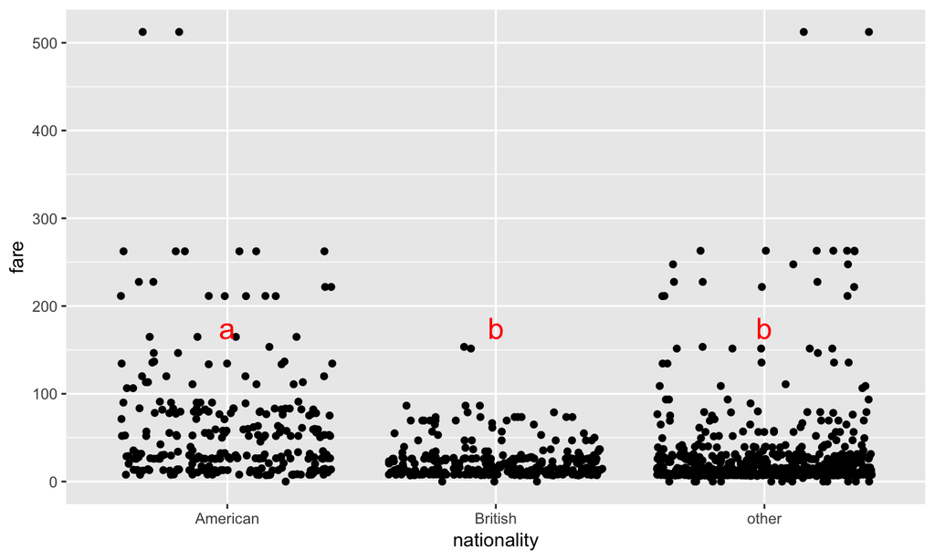

```r
p <- ggplot(titanic, aes(x = nationality, y = fare))
p + geom_jitter() +
  geom_text(data = label_table,
            aes(x = x.valuez,  y = y.valuez, label = letterz),
            color = "red", size = 6)
```

## Step 5:

Have fun!!!

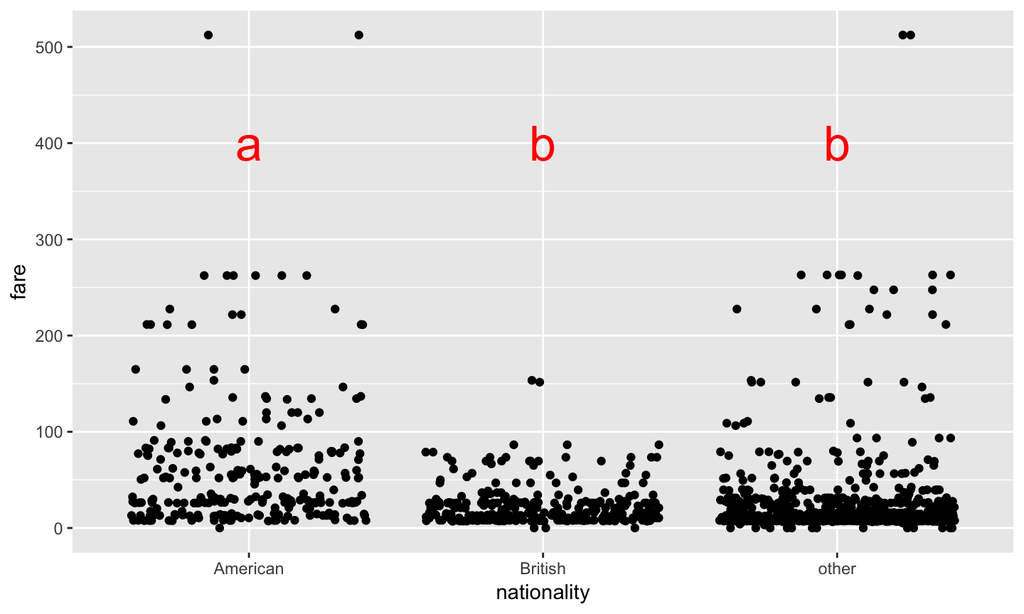

```r
p <- ggplot(titanic, aes(x = nationality, y = fare))
p + geom_jitter() +
  geom_text(data = label_table,
            aes(x = x.valuez,  y = 400, label = letterz),
            color = "red", size = 9)
```

## Step 5:

Have fun!!!

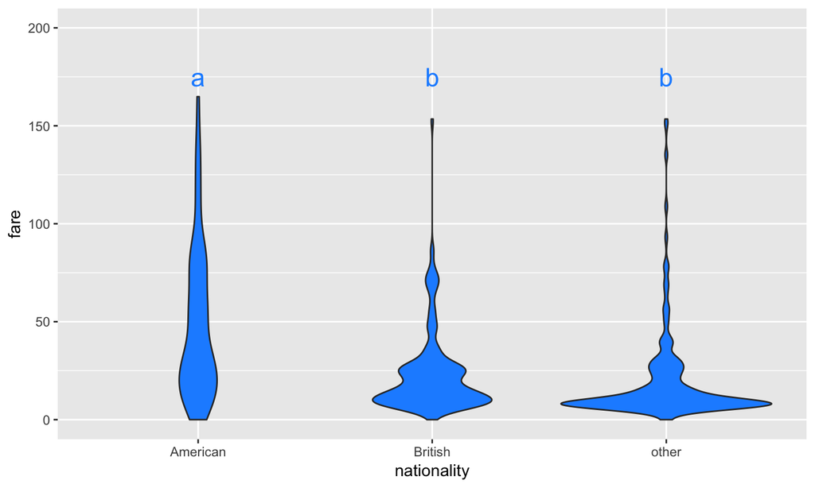

```r
p <- ggplot(titanic, aes(x = nationality, y = fare))
p + geom_violin(fill = "dodgerblue") + ylim(0,200) +
  geom_text(data = label_table,
            aes(x = x.valuez,  y = y.valuez, label = letterz),
            color = "dodgerblue", size = 6)
```

## Step 5:

Have fun!!!

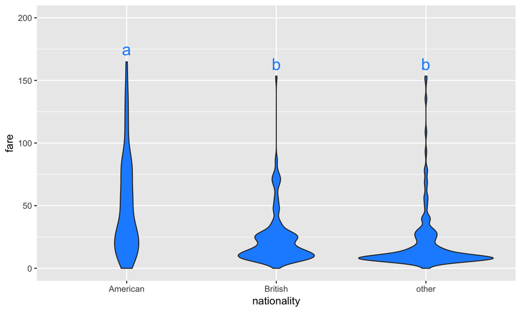

```r
p <- ggplot(titanic, aes(x = nationality, y = fare))
p + geom_violin(fill = "dodgerblue") + ylim(0,200) +
  geom_text(data = label_table,
            aes(x = x.valuez,  y = c(175, 163, 163), label = letterz),
            color = "dodgerblue", size = 6)
```

## Step 5:

Have fun!!!

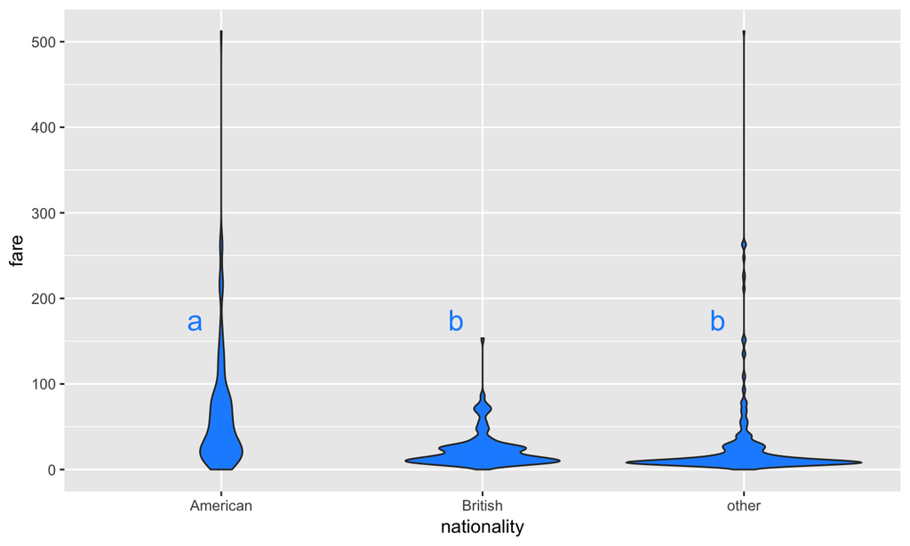

```r
p <- ggplot(titanic, aes(x = nationality, y = fare))
p + geom_violin(fill = "dodgerblue") +
  geom_text(data = label_table,
            aes(x = x.valuez - 0.1,  y = y.valuez, label = letterz),
            color = "dodgerblue", size = 6)
```

## Step 5:

Have fun!!!

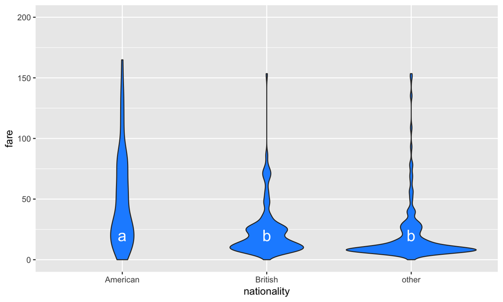

```r
p <- ggplot(titanic, aes(x = nationality, y = fare))
p + geom_violin(fill = "dodgerblue") + ylim(0,200) +
  geom_text(data = label_table,
            aes(x = x.valuez,  y = 20, label = letterz),
            color = "white", size = 6)
```